# DEMO : Spinal Cord Axis Projection Example

Alma Andersson

2021-10-01

## Prep

This notebook illustrates how the distribution of certain features of interest (e.g., genes or cell types) along a specified axis can be analyzed. To simplify things, I’ve written the code as a small package that you can load functions from. These functions are written to be versatile and general, as to allow custom analysis of different kinds.

**NOTE** : This is just a demo and not meant to be a comprehensive discussion on the actual code.

The first thing you need to do is to specify the paths to your data (`DATA_PATH`):

```r
DATA_PATH <- "../../data/robjs/210902_SC_DVaxis.rds"
```

Unsurprisingly, the next thing we do is to load the necessary packages (mainly so that we can read your `Seurat` object) and source the custom functions.

```r
library(Seurat)
```

```r
library(ggplot2)
library(gridExtra)
```

We proceed to install and load the package I’ve written for you. We fetch this package from `github`:

```r
if (!("axis.projection" %in% rownames(installed.packages()))){
   devtools::install_github("git@github.com:almaan/axis-projection.git")
}

library(axis.projection)
```

## Data loading and processing

We will now load the data that we want to analyze (your `Seurat` object), and make some small adjustments to make it easier to analyze it.

```r
se <- readRDS(DATA_PATH)
head(se@meta.data[c("labels","axis_annot")])
```

```
##                         labels axis_annot
## ATGGATCCGGCGTCCG-1_1 section_1        1_D
## GGATTCCGCTATACCC-1_1 section_1        1_D
## ATGCCGGTTGATGGGA-1_1 section_1        1_D
## TGAGCTTTAATGACGC-1_1 section_1        1_D
## ATATCTCCCTCGTTAA-1_1 section_1        1_D
## TCGCTAAACCGCTATC-1_1 section_1        1_D
```

While it’s nice that the column `axis_annot` in the metadata also contains the section information, this complicates things a bit when we want to identify the DV axis, the main issue being that a spit annotated as `1_D` would be interpret as something different than for example `2_D`, when both spots should be considered as *dorsal*. Also, there were some inconsistencies in the naming of these sections (different arrangement of "_" and numbers). Hence, we’ll adjust this before proceeding - the updated annotations will be placed in a new column called `DV`, where we only have the “D” and “V” annotation.

```r
# create a DV column
se@meta.data["DV"] <- gsub("[1-9]|_","",se@meta.data$axis_annot)
```

Since this is only a demo, we’ll only use 4 of the sections you’ve identified in the `labels` column, but of course the same workflow can be applied to the complete data set. I’ve written the code to be memory efficient, so it should not be any issues increasing the amount of data.

```r
# list which sections you want to keep
keep.sections <- paste0("section_",c(12,15,19,23))
# print info
print(sprintf("Well keep the sections >> %s",paste(keep.sections,collapse=", ")))
```

```
## [1] "Well keep the sections >> section_12, section_15, section_19, section_23"
```

```r
# select spots belonging to sections
keep.spots <- which(se@meta.data$labels %in% keep.sections)
# subset data, make sure to use the SubsetSTData to correctly modify Staffli object
se <- STutility::SubsetSTData(se,spots = keep.spots)
# inspect new object
se
```

```
## An object of class Seurat
## 30114 features across 1153 samples within 2 assays
## Active assay: SCT (15057 features, 3000 variable features)
##  1 other assay present: RNA
##  3 dimensional reductions calculated: pca, harmony, umap
```

## Analysis : Axis projection

We may now actually analyze the data. In order to do this we must do two things:

1. From knowing which spots that are in the *dorsal* respectively *ventral* parts, we need to computationally **identify the DV-axis**. The way I’ve approached this issue to, for every spot marked as *ventral* compute the vector that connects it with it’s nearest *dorsal* spot. Once these vectors are computed, they are normalized to unit norm (euclidean) and the mean is computed. From this we should end up with a fairly good estimate of the axis vector.
2. Once the DV-axis is identified, we want to project every spot onto the new space spanned by the axis vector, and extract the coordinates w.r.t. this 1D space. For this I’ve used the standard projection formula:

$proj_{\bar{v}}\bar{x} = \frac{\bar{x}\cdot\bar{v}}{\bar{v}\cdot\bar{v}}\bar{v}$

Here $\cdot$ represents the dot-product and $\bar{x}$ is the coordinates of a spot to be projected on the DV-axis ($\bar{v}$). Normalizing $\bar{v}$ to unit norm, simplifies the formula to:

$proj_{\bar{v}}\bar{x} = (\bar{x}\cdot\bar{v})\bar{v}$

from which it’s evident that the projection’s coordinate w.r.t. the basis $\bar{v}$ is simply: $\bar{x}\cdot\bar{v}$

- `ab.column` : column in the object’s `meta.data` slot that holds the annotations of whether the spots belongs to A or B. *In your case this is* `DV`
- `a.label` : label used to indicate that a spot belongs to A. *In your case this is* `V`
- `b.label` : same as `a.label` but for B. In your case this is `D`.
- `split.on` : if an individual axis should be computed for subset of spots, then `split.on` should be set to the column name that assigns the spots to each of these subsets. *In your case* this should be `labels`, since you need an individual axis for each section.
- `include.orthogonal` : By setting this to true, we also get the projections on the axis orthogonal to the ab-axis.

```r
# set argument values
ab.column <- "DV"
a.label <- "V"
b.label <- "D"
split.on <- "labels"
# indentify axis and project data on it
se <- axis.projection(se,
                      ab.column = ab.column,
                      a.label = a.label,
                      b.label = b.label,
                      split.on = split.on,
                      include.orthogonal = T
                      )
```

As another sanity check, we can plot the sections and color the spots according to their position along the axis (**note**, so far this has nothing to do with expression values). Here, a low value means that the spot is near the ventral edge while a high value means the spot is near the dorsal edge.

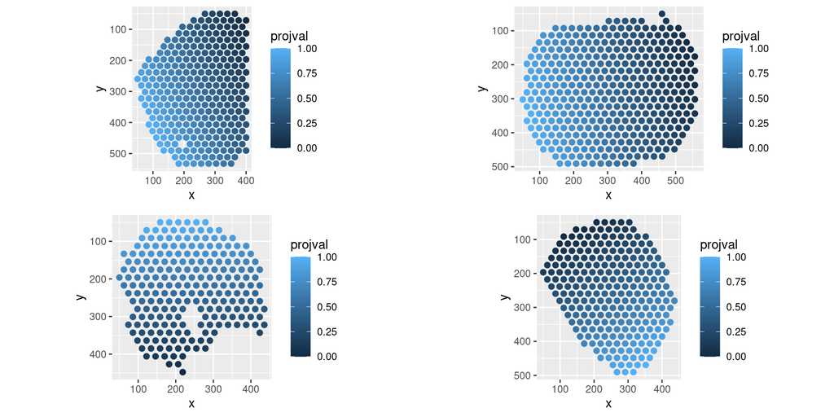

```r
# create empty list for grobs
grobs <- list()
# iterate over each section
for (s in keep.sections){

  # select spot for section
  test.spots <- which(se@meta.data$labels == s)
  # select coordinates for section
  crd <- get.coordinates(STutility::SubsetSTData(se,spots = test.spots))
  # get projected data
  proj.val <- se@meta.data$DV_projection[test.spots]
#  proj.val <- se@meta.data$orth_to_DV_projection[test.spots]

  # create data frame for plotting
  test.plot.df <- data.frame(x= crd$pixel_x,
                             y = crd$pixel_y,
                             projval = proj.val
                             )

  # create plot and store in list
  grobs[[s]] <- ggplot(test.plot.df, aes(x=x,
                                         y = y,
                                         color = projval,
                                         fill = projval)) +
                geom_point(size = 2) +
                coord_fixed() +
                scale_y_reverse()
}

# visualize subplots in grid
grid.arrange(grobs = grobs,
             ncol = 2)
```

That looks good, seems like the linear algebra implementations in the `axis.projection` function works as expected.

This means that we’re now ready to actually look at the distribution of a feature of interest along this axis.

### Visualization

The functions in the package `axis projection` are written to extract information from the *default* assay in you *Seurat* object, so make sure to that you have the correct value set here. For example, I want the `SCT` normalized data, and hence we do:

```r
# set default assay to SCT
Seurat::DefaultAssay(object = se) <- "SCT"
```

Next, let us specify the features we want to investigate:

```r
# specify genes to investigate
features <- c("EBF1", "ZIC2","FGFBP3")
```

To visualize the collective distribution along the DV-axis across all four samples we do:

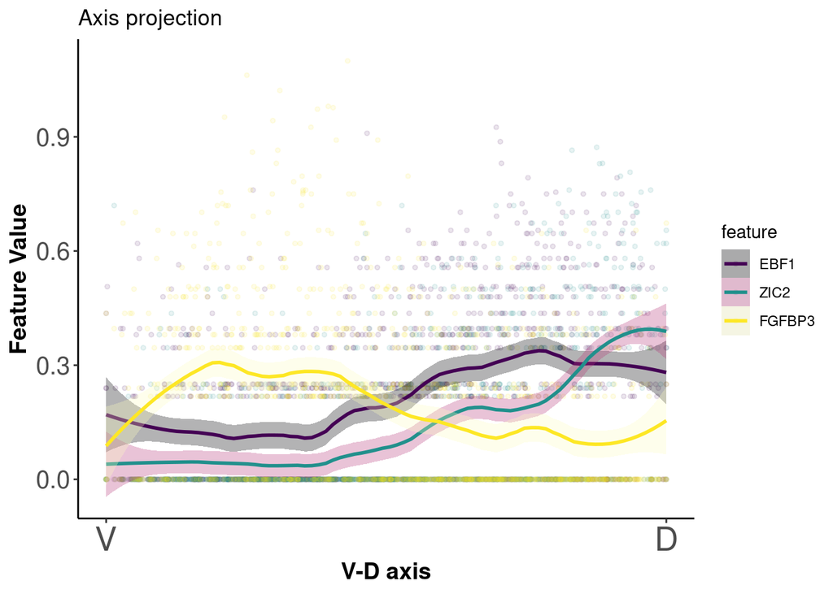

```r
# visualize features along axis
g <- plot.axis.projection(se,
                          features,
                          ab.column,
                          a.label,
                          b.label,
                          normalize = T
                          )
print(g)
```

As we can see here, the expression levels of *EBF1* and *ZIC2* increase the closer to the dorsal edge that we get, while the converse is true for *FGFBP3*.

We could also split the curves based on section, which might be handy when looking at how these expression patterns change over time. To do this, all you need to do is to *provide the name of the column you want to split the data with respect to* (for you `labels`).

For example:

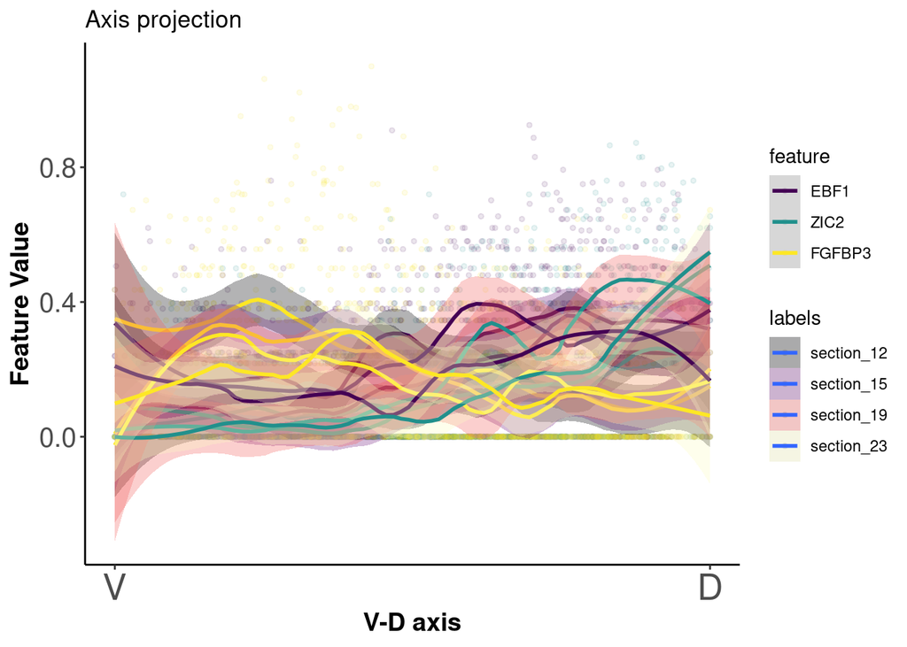

```r
# visualize features along axis
g <- plot.axis.projection(se,
                          features,
                          ab.column,
                          a.label,
                          b.label,
                          normalize = T,
                          split.on = "labels"
                          )
print(g)
```

Here features will have the same line color while the attribute you split w.r.t have a different fill color. With 3 genes and 4 samples we get 12 curves in total, which might be a bit messy. To circumvent this mess you can simply split the results into several subplots. Also, the observed values (to which we have fitted the smoothed curves), can be excluded from the visualization by setting `show.data = FALSE`.

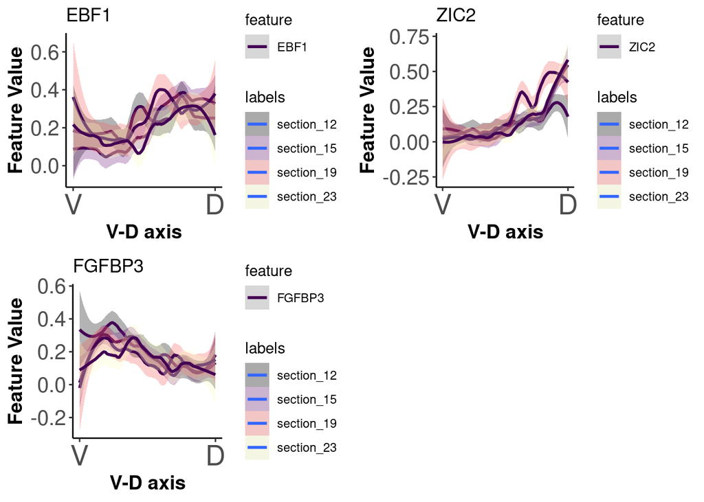

```r
# visualize features along axis
# one subplot for each feature
grobs <- lapply(features,
                function(feature){plot.axis.projection(se,
                          feature,
                          ab.column,
                          a.label,
                          b.label,
                          show.data =F,
                          normalize = T,
                          title = feature,
                          split.on = "labels"
                          )})

# visualize in grid
grid.arrange(grobs = grobs,
             ncol = 2)
```

You could also use different color palettes for the color and fill, to do this just provide these as values to the arguments `color.color` and `fill.color`. If you want to change the x-and ylabels, you can use the `xlabel` and `ylabel` arguments.

```r
# visualize
g <- plot.axis.projection(se,
                          features[1],
                          ab.column,
                          a.label,
                          b.label,
                          normalize = T,
                          split.on = "labels",
                          color.color = scale_color_hue(),
                          fill.color = scale_color_hue(),
                          xlabel = "Axis",
                          ylabel = "Gene Expression"
                          )
```

[output not shown]

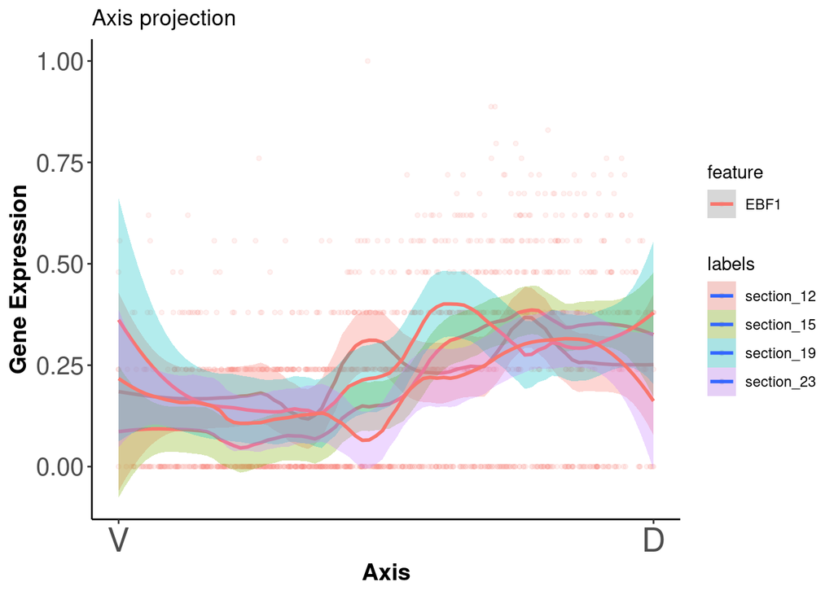

```r
print(g)
```

## Finding spatially informative genes

Next thing for us to do is to try and extract a set of genes that are highly informative of the spatial position along the DV-axis and the axis orthogonal to this one.

The way we’ll do this is by penalized logistic regression (more specifically we apply a form of L2 regression), where we try to predict the position along each axis from the gene expression. Although logistic regression is often applied to Bernoulli distributed variables, it can also be applied to continous variables like our axis positions. Logistic regression is also fit for this problem since the logit function maps values on the real number line to the interval $(0,1)$, which is exactly the values our axis-projections takes.

The generalized linear model (GLM) we are using for the fitting doesn’t scale that well to large datasets with plenty of features (like ours), so I’ve implemented a form of binning where samples that has approximately the same axis-coordinates are joined together and average expression profiles for them are calculated. By binning the data, we can make use of all the information but still keep the time for the analysis within reasonable time.

All the machinery that is needed to extract a set of spatially informative genes (SIGs) is spread across several functions that have been strung together in the `get.axis.genes` function. You can change the number of bins as well as the number of genes to extract by the arguments `n.bins` and `n.genes` respectively.

Here we’ll extract $1500$ genes associated with the DV-axis and $1500$ genes associated with the axis that is orthogonal to the DV-axis, and then join them together.

```r
set.seed(1337)

y.var.dv <- se@meta.data$DV_projection
y.var.dvo <- se@meta.data$orth_to_DV_projection

X.var <- t(as.matrix(se@assays$SCT[,]))

dv.axis.genes <- get.axis.genes(X.var,
                                y.var.dv,
                                bin.data = T,
                                n.bins = 100,
                                n.genes = 1500)
```

```
## 12345678910111213141516171819202122232425262728293031323334353637
```

```r
dvo.axis.genes <- get.axis.genes(X.var,
                                 y.var.dvo,
                                 bin.data = T,
                                 n.bins = 100,
                                 n.genes = 1500)
```

```
## 123456789101112131415161718192021222324252627282930313233343536
```

```r
axis.genes <- unique(c(dv.axis.genes,dvo.axis.genes))
var.genes <- se@assays$SCT@var.features
print(sprintf("SI and HVG gene info | [HVGs] : %d | [SIGs] : %d | [Intersection] : %d ",length(var.genes),
              length(axis.genes),length(intersect(var.genes,axis.genes))))
```

```
## [1] "SI and HVG gene info | [HVGs] : 3000 | [SIGs] : 2629 | [Intersection] : 690 "
```

As you can see there’s quite a difference between the two gene sets, I would recommend you to try to: 1. Conduct the analysis with only the SIG set 2. Conduct the analysis with the union of the HVG and SIG sets

Also, as a sanity check we can see if the SIG genes actually seem to exhibit a spatial character. Let us plot the top 5 (highest ranked) SIG genes associated with the DV-axis.

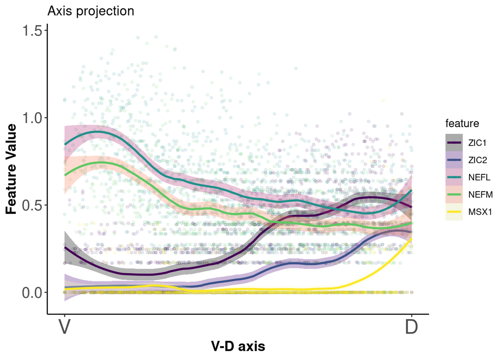

```r
# visualize features along axis
g <- plot.axis.projection(se,
                          dv.axis.genes[1:5],
                          ab.column,
                          a.label,
                          b.label,
                          normalize = T
                          )
print(g)
```

Seems like we found some nice patterns there!

## Final Remarks

This is just a brief demo on how to use the functions I’ve written for you, let me know if there are any questions. If you’re interested in the actual code itself, have a look at [this](https://github.com/almaan/axis-projection/tree/master/R).